# Intro to R Workshop: Session 3

April 13, 2017

## Session 3 - Agenda

1. Statistical Distributions in R

## Statistical Distributions in R:

- R has many built-in statistical distributions
  - e.g., binomial, poisson, normal, chi square, …
- Each distribution in R has four functions:
  - These functions begin with a "d", "p", "q", or "r" and are followed by the name of the distribution
- `ddist()`: gives the density of the distribution
- `rdist()`: generates random numbers out of the distribution
- `qdist()`: gives the quantile of the distribution
- `pdist()`: gives the cumulative distribution function (CDF)

## Discrete Distribution: Binomial

- Consider tossing a coin 10 times
- The probability distribution for the two possible outcomes follows a binomial distribution
- Let's calculate the probability of getting five heads using the function `dbinom()`

```r
str(dbinom) # binomial probability mass func
```

```
## function (x, size, prob, log = FALSE)
```

```r
dbinom(5, 10, 0.5) # Pr[X = 5] = ?
```

```
## [1] 0.2460938
```

## Discrete Distribution: Binomial

- Next, let's calculate the probability of getting 5 or fewer heads using the function `pbinom()`

```r
str(pbinom) # binomial CDF
```

```
## function (q, size, prob, lower.tail = TRUE, log.p = FALSE)
```

```r
pbinom(5, 10, 0.5) # Pr[X <= 5] = ?
```

```
## [1] 0.6230469
```

## Discrete Distribution: Binomial

```r
str(qbinom) # binomial quantile func
```

```
## function (p, size, prob, lower.tail = TRUE, log.p = FALSE)
```

```r
qbinom(0.75, 10, 0.5) # get the value of ? s.t. Pr[X <= ?] = 0.75
```

```
## [1] 6
```

## Discrete Distribution: Binomial

- Finally, let's generate 20 independent samples from a binomial(10, 0.5). This is equivalent to repeatedly (i.e., 20 times) flipping a coin 10 times and counting the number of heads.

```r
str(rbinom) # binomial random number generator
```

```
## function (n, size, prob)
```

```r
rbinom(20, 10, 0.5) # 20 ind samples from binomial(10, 0.5)
```

```
##  [1] 4 4 5 4 6 8 7 5 6 3 4 4 6 6 4 4 6 4 5 7
```

## Continuous Distribution: Standard Normal

- Calculate the value of the probability density function at \(X = 0\)

```r
str(dnorm) # normal pdf
```

```
## function (x, mean = 0, sd = 1, log = FALSE)
```

```r
dnorm(x = 0, mean = 0, sd = 1)
```

```
## [1] 0.3989423
```

## Continuous Distribution: Standard Normal

- Calculate the probability that \(X \leq 0\)

```r
str(pnorm) # normal CDF
```

```
## function (q, mean = 0, sd = 1, lower.tail = TRUE, log.p = FALSE)
```

```r
pnorm(0, mean = 0, sd = 1) # Pr[X <= 0] = ?
```

```
## [1] 0.5
```

## Continuous Distribution: Standard Normal

- Find the value for which the CDF = 0.975

```r
str(qnorm) # normal quantile func
```

```
## function (p, mean = 0, sd = 1, lower.tail = TRUE, log.p = FALSE)
```

```r
qnorm(0.975, mean = 0, sd = 1) # PR[X <= ?] = 0.975
```

```
## [1] 1.959964
```

## Continuous Distribution: Standard Normal

- Generate 10 independent random numbers from a standard normal distribution

```r
str(rnorm) # generate random number from normal dist
```

```
## function (n, mean = 0, sd = 1)
```

```r
rnorm(10, mean = 0, sd = 1)
```

```
##  [1]  0.28732831  1.28870120  0.95492333 -1.05616106  0.71571889
##  [6] -0.06861534  0.25125574  1.13770718  0.31197057  1.73683798
```

Let's try plotting a normal curve (more on plotting later)

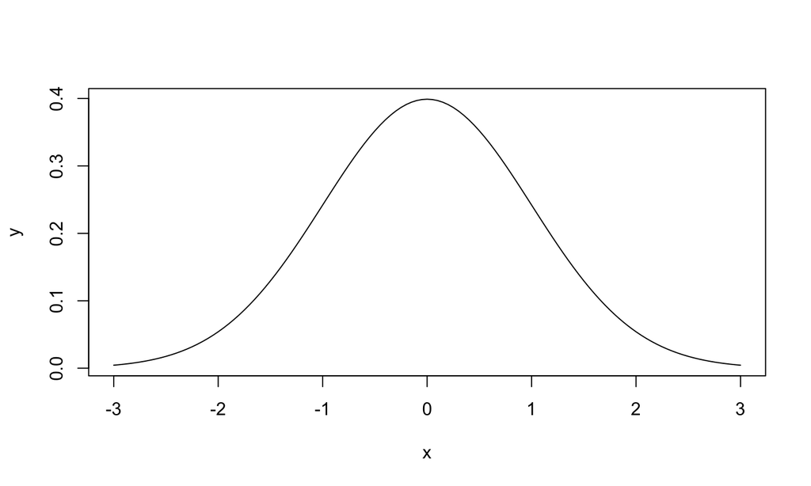

```r
x <- seq(from = -3, to = 3, by = 0.05)
y <- dnorm(x, mean = 0, sd = 1)
plot(x, y, type = "l")
```